# Risk Factor Analysis

## Outcome Variable

**Outcome Variable:** ever_co

## Predictor Variables

**Intervention Variable:** meducyrs

**Adjustment Set:**

- arm
- W_mage
- feducyrs
- W_mhtcm
- W_gagebrth
- W_birthwt
- W_birthlen
- single
- delta_W_mage
- delta_feducyrs
- delta_W_mhtcm
- delta_W_gagebrth
- delta_W_birthwt
- delta_W_birthlen
- delta_single

## Stratifying Variables

The analysis was stratified on these variable(s):

- agecat
- studyid
- country

## Data Summary

| agecat | studyid | country | meducyrs | ever_co | n_cell | n |
| --- | --- | --- | --- | --- | --- | --- |
| 0-24 months | ki0047075b-MAL-ED | BANGLADESH | High | 0 | 70 | 213 |
| 0-24 months | ki0047075b-MAL-ED | BANGLADESH | High | 1 | 8 | 213 |
| 0-24 months | ki0047075b-MAL-ED | BANGLADESH | Low | 0 | 61 | 213 |
| 0-24 months | ki0047075b-MAL-ED | BANGLADESH | Low | 1 | 9 | 213 |
| 0-24 months | ki0047075b-MAL-ED | BANGLADESH | Medium | 0 | 58 | 213 |
| 0-24 months | ki0047075b-MAL-ED | BANGLADESH | Medium | 1 | 7 | 213 |
| 0-24 months | ki0047075b-MAL-ED | BRAZIL | High | 0 | 79 | 232 |
| 0-24 months | ki0047075b-MAL-ED | BRAZIL | High | 1 | 0 | 232 |
| 0-24 months | ki0047075b-MAL-ED | BRAZIL | Low | 0 | 61 | 232 |
| 0-24 months | ki0047075b-MAL-ED | BRAZIL | Low | 1 | 2 | 232 |
| 0-24 months | ki0047075b-MAL-ED | BRAZIL | Medium | 0 | 90 | 232 |
| 0-24 months | ki0047075b-MAL-ED | BRAZIL | Medium | 1 | 0 | 232 |
| 0-24 months | ki0047075b-MAL-ED | INDIA | High | 0 | 54 | 220 |
| 0-24 months | ki0047075b-MAL-ED | INDIA | High | 1 | 9 | 220 |
| 0-24 months | ki0047075b-MAL-ED | INDIA | Low | 0 | 61 | 220 |
| 0-24 months | ki0047075b-MAL-ED | INDIA | Low | 1 | 15 | 220 |
| 0-24 months | ki0047075b-MAL-ED | INDIA | Medium | 0 | 60 | 220 |
| 0-24 months | ki0047075b-MAL-ED | INDIA | Medium | 1 | 21 | 220 |
| 0-24 months | ki0047075b-MAL-ED | NEPAL | High | 0 | 50 | 225 |
| 0-24 months | ki0047075b-MAL-ED | NEPAL | High | 1 | 3 | 225 |
| 0-24 months | ki0047075b-MAL-ED | NEPAL | Low | 0 | 85 | 225 |
| 0-24 months | ki0047075b-MAL-ED | NEPAL | Low | 1 | 11 | 225 |
| 0-24 months | ki0047075b-MAL-ED | NEPAL | Medium | 0 | 71 | 225 |
| 0-24 months | ki0047075b-MAL-ED | NEPAL | Medium | 1 | 5 | 225 |
| 0-24 months | ki0047075b-MAL-ED | PERU | High | 0 | 89 | 301 |
| 0-24 months | ki0047075b-MAL-ED | PERU | High | 1 | 1 | 301 |
| 0-24 months | ki0047075b-MAL-ED | PERU | Low | 0 | 100 | 301 |
| 0-24 months | ki0047075b-MAL-ED | PERU | Low | 1 | 4 | 301 |
| 0-24 months | ki0047075b-MAL-ED | PERU | Medium | 0 | 100 | 301 |
| 0-24 months | ki0047075b-MAL-ED | PERU | Medium | 1 | 7 | 301 |

[output cut: 438 more lines]

The following strata were considered:

- agecat: 0-24 months, studyid: ki0047075b-MAL-ED, country: BANGLADESH
- agecat: 0-24 months, studyid: ki0047075b-MAL-ED, country: BRAZIL
- agecat: 0-24 months, studyid: ki0047075b-MAL-ED, country: INDIA
- agecat: 0-24 months, studyid: ki0047075b-MAL-ED, country: NEPAL
- agecat: 0-24 months, studyid: ki0047075b-MAL-ED, country: PERU
- agecat: 0-24 months, studyid: ki0047075b-MAL-ED, country: SOUTH AFRICA
- agecat: 0-24 months, studyid: ki0047075b-MAL-ED, country: TANZANIA, UNITED REPUBLIC OF
- agecat: 0-24 months, studyid: ki1000108-CMC-V-BCS-2002, country: INDIA
- agecat: 0-24 months, studyid: ki1000108-IRC, country: INDIA
- agecat: 0-24 months, studyid: ki1000109-EE, country: PAKISTAN
- agecat: 0-24 months, studyid: ki1000304b-SAS-CompFeed, country: INDIA
- agecat: 0-24 months, studyid: ki1000304b-SAS-FoodSuppl, country: INDIA
- agecat: 0-24 months, studyid: ki1017093-NIH-Birth, country: BANGLADESH
- agecat: 0-24 months, studyid: ki1017093b-PROVIDE, country: BANGLADESH
- agecat: 0-24 months, studyid: ki1017093c-NIH-Crypto, country: BANGLADESH
- agecat: 0-24 months, studyid: ki1066203-TanzaniaChild2, country: TANZANIA, UNITED REPUBLIC OF
- agecat: 0-24 months, studyid: ki1112895-Guatemala BSC, country: GUATEMALA
- agecat: 0-24 months, studyid: ki1113344-GMS-Nepal, country: NEPAL
- agecat: 0-24 months, studyid: ki1119695-PROBIT, country: BELARUS
- agecat: 0-24 months, studyid: ki1126311-ZVITAMBO, country: ZIMBABWE
- agecat: 0-24 months, studyid: ki1135781-COHORTS, country: GUATEMALA
- agecat: 0-24 months, studyid: ki1135781-COHORTS, country: INDIA
- agecat: 0-24 months, studyid: ki1135781-COHORTS, country: PHILIPPINES
- agecat: 0-24 months, studyid: ki1148112-LCNI-5, country: MALAWI
- agecat: 0-24 months, studyid: kiGH5241-JiVitA-3, country: BANGLADESH
- agecat: 0-24 months, studyid: kiGH5241-JiVitA-4, country: BANGLADESH
- agecat: 0-6 months, studyid: ki0047075b-MAL-ED, country: BANGLADESH
- agecat: 0-6 months, studyid: ki0047075b-MAL-ED, country: BRAZIL
- agecat: 0-6 months, studyid: ki0047075b-MAL-ED, country: INDIA
- agecat: 0-6 months, studyid: ki0047075b-MAL-ED, country: NEPAL
- agecat: 0-6 months, studyid: ki0047075b-MAL-ED, country: PERU
- agecat: 0-6 months, studyid: ki0047075b-MAL-ED, country: SOUTH AFRICA
- agecat: 0-6 months, studyid: ki0047075b-MAL-ED, country: TANZANIA, UNITED REPUBLIC OF
- agecat: 0-6 months, studyid: ki1000108-CMC-V-BCS-2002, country: INDIA
- agecat: 0-6 months, studyid: ki1000108-IRC, country: INDIA
- agecat: 0-6 months, studyid: ki1000109-EE, country: PAKISTAN
- agecat: 0-6 months, studyid: ki1000304b-SAS-CompFeed, country: INDIA
- agecat: 0-6 months, studyid: ki1000304b-SAS-FoodSuppl, country: INDIA
- agecat: 0-6 months, studyid: ki1017093-NIH-Birth, country: BANGLADESH
- agecat: 0-6 months, studyid: ki1017093b-PROVIDE, country: BANGLADESH
- agecat: 0-6 months, studyid: ki1017093c-NIH-Crypto, country: BANGLADESH
- agecat: 0-6 months, studyid: ki1066203-TanzaniaChild2, country: TANZANIA, UNITED REPUBLIC OF
- agecat: 0-6 months, studyid: ki1112895-Guatemala BSC, country: GUATEMALA
- agecat: 0-6 months, studyid: ki1113344-GMS-Nepal, country: NEPAL
- agecat: 0-6 months, studyid: ki1119695-PROBIT, country: BELARUS
- agecat: 0-6 months, studyid: ki1126311-ZVITAMBO, country: ZIMBABWE
- agecat: 0-6 months, studyid: ki1135781-COHORTS, country: GUATEMALA
- agecat: 0-6 months, studyid: ki1135781-COHORTS, country: INDIA
- agecat: 0-6 months, studyid: ki1135781-COHORTS, country: PHILIPPINES
- agecat: 0-6 months, studyid: ki1148112-LCNI-5, country: MALAWI
- agecat: 0-6 months, studyid: kiGH5241-JiVitA-3, country: BANGLADESH
- agecat: 0-6 months, studyid: kiGH5241-JiVitA-4, country: BANGLADESH
- agecat: 6-24 months, studyid: ki0047075b-MAL-ED, country: BANGLADESH
- agecat: 6-24 months, studyid: ki0047075b-MAL-ED, country: BRAZIL
- agecat: 6-24 months, studyid: ki0047075b-MAL-ED, country: INDIA
- agecat: 6-24 months, studyid: ki0047075b-MAL-ED, country: NEPAL
- agecat: 6-24 months, studyid: ki0047075b-MAL-ED, country: PERU
- agecat: 6-24 months, studyid: ki0047075b-MAL-ED, country: SOUTH AFRICA
- agecat: 6-24 months, studyid: ki0047075b-MAL-ED, country: TANZANIA, UNITED REPUBLIC OF
- agecat: 6-24 months, studyid: ki1000108-CMC-V-BCS-2002, country: INDIA
- agecat: 6-24 months, studyid: ki1000108-IRC, country: INDIA
- agecat: 6-24 months, studyid: ki1000109-EE, country: PAKISTAN
- agecat: 6-24 months, studyid: ki1000304b-SAS-CompFeed, country: INDIA
- agecat: 6-24 months, studyid: ki1000304b-SAS-FoodSuppl, country: INDIA
- agecat: 6-24 months, studyid: ki1017093-NIH-Birth, country: BANGLADESH
- agecat: 6-24 months, studyid: ki1017093b-PROVIDE, country: BANGLADESH
- agecat: 6-24 months, studyid: ki1017093c-NIH-Crypto, country: BANGLADESH
- agecat: 6-24 months, studyid: ki1066203-TanzaniaChild2, country: TANZANIA, UNITED REPUBLIC OF
- agecat: 6-24 months, studyid: ki1112895-Guatemala BSC, country: GUATEMALA
- agecat: 6-24 months, studyid: ki1113344-GMS-Nepal, country: NEPAL
- agecat: 6-24 months, studyid: ki1119695-PROBIT, country: BELARUS
- agecat: 6-24 months, studyid: ki1126311-ZVITAMBO, country: ZIMBABWE
- agecat: 6-24 months, studyid: ki1135781-COHORTS, country: GUATEMALA
- agecat: 6-24 months, studyid: ki1135781-COHORTS, country: INDIA
- agecat: 6-24 months, studyid: ki1135781-COHORTS, country: PHILIPPINES
- agecat: 6-24 months, studyid: ki1148112-LCNI-5, country: MALAWI
- agecat: 6-24 months, studyid: kiGH5241-JiVitA-3, country: BANGLADESH
- agecat: 6-24 months, studyid: kiGH5241-JiVitA-4, country: BANGLADESH

### Dropped Strata

Some strata were dropped due to rare outcomes:

- agecat: 0-24 months, studyid: ki0047075b-MAL-ED, country: BRAZIL
- agecat: 0-24 months, studyid: ki0047075b-MAL-ED, country: NEPAL
- agecat: 0-24 months, studyid: ki0047075b-MAL-ED, country: PERU
- agecat: 0-24 months, studyid: ki0047075b-MAL-ED, country: SOUTH AFRICA
- agecat: 0-24 months, studyid: ki0047075b-MAL-ED, country: TANZANIA, UNITED REPUBLIC OF
- agecat: 0-24 months, studyid: ki1000109-EE, country: PAKISTAN
- agecat: 0-24 months, studyid: ki1112895-Guatemala BSC, country: GUATEMALA
- agecat: 0-24 months, studyid: ki1119695-PROBIT, country: BELARUS
- agecat: 0-6 months, studyid: ki0047075b-MAL-ED, country: BANGLADESH
- agecat: 0-6 months, studyid: ki0047075b-MAL-ED, country: BRAZIL
- agecat: 0-6 months, studyid: ki0047075b-MAL-ED, country: INDIA
- agecat: 0-6 months, studyid: ki0047075b-MAL-ED, country: NEPAL
- agecat: 0-6 months, studyid: ki0047075b-MAL-ED, country: PERU
- agecat: 0-6 months, studyid: ki0047075b-MAL-ED, country: SOUTH AFRICA
- agecat: 0-6 months, studyid: ki0047075b-MAL-ED, country: TANZANIA, UNITED REPUBLIC OF
- agecat: 0-6 months, studyid: ki1000109-EE, country: PAKISTAN
- agecat: 0-6 months, studyid: ki1000304b-SAS-FoodSuppl, country: INDIA
- agecat: 0-6 months, studyid: ki1017093c-NIH-Crypto, country: BANGLADESH
- agecat: 0-6 months, studyid: ki1066203-TanzaniaChild2, country: TANZANIA, UNITED REPUBLIC OF
- agecat: 0-6 months, studyid: ki1112895-Guatemala BSC, country: GUATEMALA
- agecat: 0-6 months, studyid: ki1113344-GMS-Nepal, country: NEPAL
- agecat: 0-6 months, studyid: ki1119695-PROBIT, country: BELARUS
- agecat: 0-6 months, studyid: ki1135781-COHORTS, country: GUATEMALA
- agecat: 0-6 months, studyid: ki1148112-LCNI-5, country: MALAWI
- agecat: 0-6 months, studyid: kiGH5241-JiVitA-4, country: BANGLADESH
- agecat: 6-24 months, studyid: ki0047075b-MAL-ED, country: BRAZIL
- agecat: 6-24 months, studyid: ki0047075b-MAL-ED, country: NEPAL
- agecat: 6-24 months, studyid: ki0047075b-MAL-ED, country: PERU
- agecat: 6-24 months, studyid: ki0047075b-MAL-ED, country: SOUTH AFRICA
- agecat: 6-24 months, studyid: ki0047075b-MAL-ED, country: TANZANIA, UNITED REPUBLIC OF
- agecat: 6-24 months, studyid: ki1000109-EE, country: PAKISTAN
- agecat: 6-24 months, studyid: ki1112895-Guatemala BSC, country: GUATEMALA
- agecat: 6-24 months, studyid: ki1119695-PROBIT, country: BELARUS

## Methods Detail

We’re interested in the causal parameters $E[Y_a]$ for all values of $a \in \mathcal{A}$. These parameters represent the mean outcome if, possibly contrary to fact, we intervened to set all units to have $A=a$. Under the randomization and positivity assumptions, these are identified by the statistical parameters $\psi_a=E_W[E_{Y|A,W}(Y|A=a,W)]$. In addition, we’re interested in the mean of $Y$, $E[Y]$ under no intervention (the observed mean). We will estimate these parameters by using SuperLearner to fit the relevant likelihood factors – $E_{Y|A,W}(Y|A=a,W)$ and $p(A=a|W)$, and then updating our likelihood fit using a joint TMLE.

For unadjusted analyses ($W=\{\}$), initial likelihoods were estimated using Lrnr_glm to estimate the simple $E(Y|A)$ and Lrnr_mean to estimate $p(A)$. For adjusted analyses, a small library containing Lrnr_glmnet, Lrnr_xgboost, and Lrnr_mean was used.

Having estimated these parameters, we will then use the delta method to estimate relative risks and attributable risks relative to a prespecified baseline level of $A$.

# Results Detail

## Results Plots

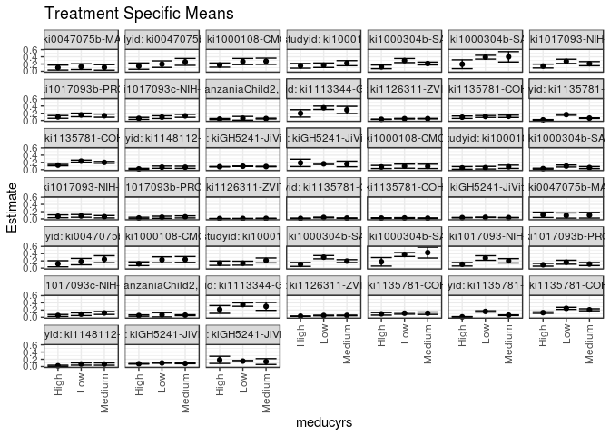

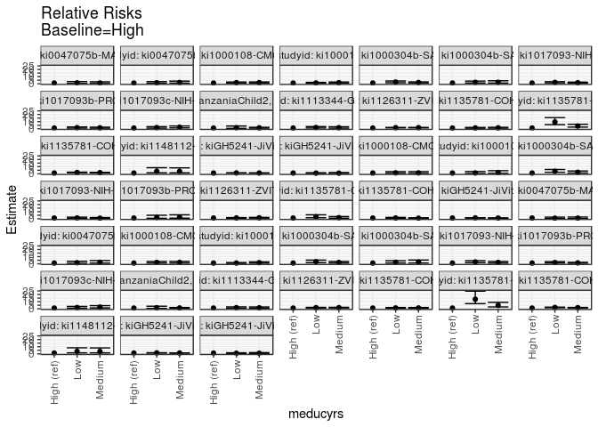

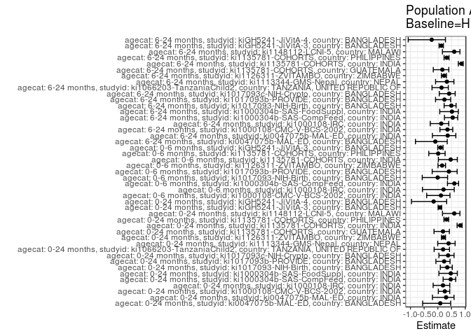

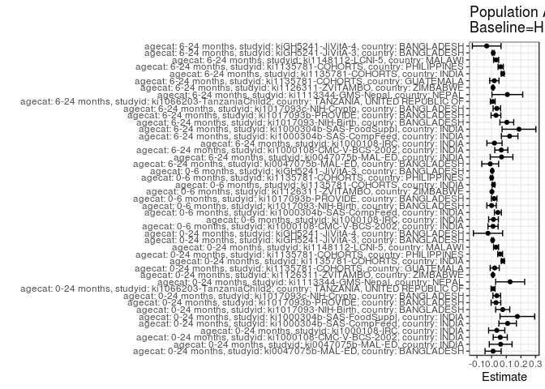

## Results Table

### Parameter: TSM

| agecat | studyid | country | intervention_level | baseline_level | estimate | ci_lower | ci_upper |
| --- | --- | --- | --- | --- | --- | --- | --- |
| 0-24 months | ki0047075b-MAL-ED | BANGLADESH | High | NA | 0.1025641 | 0.0350768 | 0.1700514 |
| 0-24 months | ki0047075b-MAL-ED | BANGLADESH | Low | NA | 0.1285714 | 0.0499739 | 0.2071690 |
| 0-24 months | ki0047075b-MAL-ED | BANGLADESH | Medium | NA | 0.1076923 | 0.0321547 | 0.1832299 |
| 0-24 months | ki0047075b-MAL-ED | INDIA | High | NA | 0.1428571 | 0.0562518 | 0.2294625 |
| 0-24 months | ki0047075b-MAL-ED | INDIA | Low | NA | 0.1973684 | 0.1076818 | 0.2870550 |
| 0-24 months | ki0047075b-MAL-ED | INDIA | Medium | NA | 0.2592593 | 0.1636070 | 0.3549115 |
| 0-24 months | ki1000108-CMC-V-BCS-2002 | INDIA | High | NA | 0.1717936 | 0.1140091 | 0.2295782 |
| 0-24 months | ki1000108-CMC-V-BCS-2002 | INDIA | Low | NA | 0.2694233 | 0.1842635 | 0.3545831 |
| 0-24 months | ki1000108-CMC-V-BCS-2002 | INDIA | Medium | NA | 0.2769700 | 0.1911719 | 0.3627682 |
| 0-24 months | ki1000108-IRC | INDIA | High | NA | 0.1506786 | 0.0866856 | 0.2146717 |
| 0-24 months | ki1000108-IRC | INDIA | Low | NA | 0.1672777 | 0.1059176 | 0.2286378 |
| 0-24 months | ki1000108-IRC | INDIA | Medium | NA | 0.2244617 | 0.1540582 | 0.2948652 |
| 0-24 months | ki1000304b-SAS-CompFeed | INDIA | High | NA | 0.1228475 | 0.0725710 | 0.1731240 |
| 0-24 months | ki1000304b-SAS-CompFeed | INDIA | Low | NA | 0.2965500 | 0.2397427 | 0.3533573 |
| 0-24 months | ki1000304b-SAS-CompFeed | INDIA | Medium | NA | 0.2144360 | 0.1756092 | 0.2532629 |
| 0-24 months | ki1000304b-SAS-FoodSuppl | INDIA | High | NA | 0.1951220 | 0.0736728 | 0.3165711 |
| 0-24 months | ki1000304b-SAS-FoodSuppl | INDIA | Low | NA | 0.3885542 | 0.3360609 | 0.4410475 |
| 0-24 months | ki1000304b-SAS-FoodSuppl | INDIA | Medium | NA | 0.4000000 | 0.2566929 | 0.5433071 |
| 0-24 months | ki1017093-NIH-Birth | BANGLADESH | High | NA | 0.1439826 | 0.0916329 | 0.1963324 |
| 0-24 months | ki1017093-NIH-Birth | BANGLADESH | Low | NA | 0.2741476 | 0.2155382 | 0.3327571 |
| 0-24 months | ki1017093-NIH-Birth | BANGLADESH | Medium | NA | 0.2103580 | 0.1528461 | 0.2678698 |
| 0-24 months | ki1017093b-PROVIDE | BANGLADESH | High | NA | 0.0991694 | 0.0614401 | 0.1368986 |
| 0-24 months | ki1017093b-PROVIDE | BANGLADESH | Low | NA | 0.1538342 | 0.1046166 | 0.2030519 |
| 0-24 months | ki1017093b-PROVIDE | BANGLADESH | Medium | NA | 0.1330566 | 0.0901604 | 0.1759528 |
| 0-24 months | ki1017093c-NIH-Crypto | BANGLADESH | High | NA | 0.0586118 | 0.0304322 | 0.0867915 |
| 0-24 months | ki1017093c-NIH-Crypto | BANGLADESH | Low | NA | 0.0934822 | 0.0562521 | 0.1307123 |
| 0-24 months | ki1017093c-NIH-Crypto | BANGLADESH | Medium | NA | 0.1290757 | 0.0882217 | 0.1699297 |
| 0-24 months | ki1066203-TanzaniaChild2 | TANZANIA, UNITED REPUBLIC OF | High | NA | 0.0402577 | 0.0247946 | 0.0557207 |
| 0-24 months | ki1066203-TanzaniaChild2 | TANZANIA, UNITED REPUBLIC OF | Low | NA | 0.0609756 | 0.0091734 | 0.1127779 |
| 0-24 months | ki1066203-TanzaniaChild2 | TANZANIA, UNITED REPUBLIC OF | Medium | NA | 0.0528818 | 0.0421875 | 0.0635761 |

[output cut: 105 more lines]

### Parameter: E(Y)

| agecat | studyid | country | intervention_level | baseline_level | estimate | ci_lower | ci_upper |
| --- | --- | --- | --- | --- | --- | --- | --- |
| 0-24 months | ki0047075b-MAL-ED | BANGLADESH | NA | NA | 0.1126761 | 0.0701126 | 0.1552395 |
| 0-24 months | ki0047075b-MAL-ED | INDIA | NA | NA | 0.2045455 | 0.1511224 | 0.2579685 |
| 0-24 months | ki1000108-CMC-V-BCS-2002 | INDIA | NA | NA | 0.2305630 | 0.1877616 | 0.2733644 |
| 0-24 months | ki1000108-IRC | INDIA | NA | NA | 0.1853659 | 0.1477057 | 0.2230261 |
| 0-24 months | ki1000304b-SAS-CompFeed | INDIA | NA | NA | 0.2319894 | 0.1917264 | 0.2722524 |
| 0-24 months | ki1000304b-SAS-FoodSuppl | INDIA | NA | NA | 0.3708134 | 0.3244530 | 0.4171738 |
| 0-24 months | ki1017093-NIH-Birth | BANGLADESH | NA | NA | 0.2195513 | 0.1870467 | 0.2520558 |
| 0-24 months | ki1017093b-PROVIDE | BANGLADESH | NA | NA | 0.1285714 | 0.1037574 | 0.1533855 |
| 0-24 months | ki1017093c-NIH-Crypto | BANGLADESH | NA | NA | 0.0936675 | 0.0729118 | 0.1144233 |
| 0-24 months | ki1066203-TanzaniaChild2 | TANZANIA, UNITED REPUBLIC OF | NA | NA | 0.0498743 | 0.0411379 | 0.0586107 |
| 0-24 months | ki1113344-GMS-Nepal | NEPAL | NA | NA | 0.3222037 | 0.2847485 | 0.3596589 |
| 0-24 months | ki1126311-ZVITAMBO | ZIMBABWE | NA | NA | 0.0418254 | 0.0384990 | 0.0451517 |
| 0-24 months | ki1135781-COHORTS | GUATEMALA | NA | NA | 0.1119516 | 0.0949484 | 0.1289548 |
| 0-24 months | ki1135781-COHORTS | INDIA | NA | NA | 0.0934771 | 0.0860112 | 0.1009431 |
| 0-24 months | ki1135781-COHORTS | PHILIPPINES | NA | NA | 0.1839080 | 0.1701456 | 0.1976705 |
| 0-24 months | ki1148112-LCNI-5 | MALAWI | NA | NA | 0.0503686 | 0.0353351 | 0.0654020 |
| 0-24 months | kiGH5241-JiVitA-3 | BANGLADESH | NA | NA | 0.0884989 | 0.0846168 | 0.0923809 |
| 0-24 months | kiGH5241-JiVitA-4 | BANGLADESH | NA | NA | 0.1625488 | 0.1455786 | 0.1795190 |
| 0-6 months | ki1000108-CMC-V-BCS-2002 | INDIA | NA | NA | 0.0842391 | 0.0558231 | 0.1126551 |
| 0-6 months | ki1000108-IRC | INDIA | NA | NA | 0.0611247 | 0.0378797 | 0.0843697 |
| 0-6 months | ki1000304b-SAS-CompFeed | INDIA | NA | NA | 0.0704787 | 0.0478990 | 0.0930584 |
| 0-6 months | ki1017093-NIH-Birth | BANGLADESH | NA | NA | 0.0723473 | 0.0519719 | 0.0927227 |
| 0-6 months | ki1017093b-PROVIDE | BANGLADESH | NA | NA | 0.0428571 | 0.0278427 | 0.0578716 |
| 0-6 months | ki1126311-ZVITAMBO | ZIMBABWE | NA | NA | 0.0120839 | 0.0102622 | 0.0139056 |
| 0-6 months | ki1135781-COHORTS | INDIA | NA | NA | 0.0266667 | 0.0224561 | 0.0308772 |
| 0-6 months | ki1135781-COHORTS | PHILIPPINES | NA | NA | 0.0236531 | 0.0182537 | 0.0290525 |
| 0-6 months | kiGH5241-JiVitA-3 | BANGLADESH | NA | NA | 0.0393116 | 0.0368259 | 0.0417973 |
| 6-24 months | ki0047075b-MAL-ED | BANGLADESH | NA | NA | 0.1030928 | 0.0601928 | 0.1459928 |
| 6-24 months | ki0047075b-MAL-ED | INDIA | NA | NA | 0.1884058 | 0.1350070 | 0.2418045 |
| 6-24 months | ki1000108-CMC-V-BCS-2002 | INDIA | NA | NA | 0.1876676 | 0.1479906 | 0.2273445 |
| 6-24 months | ki1000108-IRC | INDIA | NA | NA | 0.1560976 | 0.1209228 | 0.1912723 |
| 6-24 months | ki1000304b-SAS-CompFeed | INDIA | NA | NA | 0.2260619 | 0.1909133 | 0.2612105 |
| 6-24 months | ki1000304b-SAS-FoodSuppl | INDIA | NA | NA | 0.3615960 | 0.3145115 | 0.4086805 |
| 6-24 months | ki1017093-NIH-Birth | BANGLADESH | NA | NA | 0.2103321 | 0.1759902 | 0.2446740 |
| 6-24 months | ki1017093b-PROVIDE | BANGLADESH | NA | NA | 0.1221498 | 0.0962275 | 0.1480722 |
| 6-24 months | ki1017093c-NIH-Crypto | BANGLADESH | NA | NA | 0.0863014 | 0.0659171 | 0.1066856 |
| 6-24 months | ki1066203-TanzaniaChild2 | TANZANIA, UNITED REPUBLIC OF | NA | NA | 0.0562189 | 0.0461465 | 0.0662914 |
| 6-24 months | ki1113344-GMS-Nepal | NEPAL | NA | NA | 0.3236797 | 0.2857977 | 0.3615618 |
| 6-24 months | ki1126311-ZVITAMBO | ZIMBABWE | NA | NA | 0.0407380 | 0.0369883 | 0.0444876 |
| 6-24 months | ki1135781-COHORTS | GUATEMALA | NA | NA | 0.1136174 | 0.0956322 | 0.1316026 |
| 6-24 months | ki1135781-COHORTS | INDIA | NA | NA | 0.0876552 | 0.0801645 | 0.0951460 |
| 6-24 months | ki1135781-COHORTS | PHILIPPINES | NA | NA | 0.1908832 | 0.1763448 | 0.2054216 |
| 6-24 months | ki1148112-LCNI-5 | MALAWI | NA | NA | 0.0510585 | 0.0358245 | 0.0662926 |
| 6-24 months | kiGH5241-JiVitA-3 | BANGLADESH | NA | NA | 0.0868381 | 0.0821743 | 0.0915020 |
| 6-24 months | kiGH5241-JiVitA-4 | BANGLADESH | NA | NA | 0.1503694 | 0.1342222 | 0.1665166 |

### Parameter: RR

| agecat | studyid | country | intervention_level | baseline_level | estimate | ci_lower | ci_upper |
| --- | --- | --- | --- | --- | --- | --- | --- |
| 0-24 months | ki0047075b-MAL-ED | BANGLADESH | High | High | 1.0000000 | 1.0000000 | 1.000000 |
| 0-24 months | ki0047075b-MAL-ED | BANGLADESH | Low | High | 1.2535714 | 0.5106086 | 3.077585 |
| 0-24 months | ki0047075b-MAL-ED | BANGLADESH | Medium | High | 1.0500000 | 0.4013361 | 2.747074 |
| 0-24 months | ki0047075b-MAL-ED | INDIA | High | High | 1.0000000 | 1.0000000 | 1.000000 |
| 0-24 months | ki0047075b-MAL-ED | INDIA | Low | High | 1.3815789 | 0.6476465 | 2.947226 |
| 0-24 months | ki0047075b-MAL-ED | INDIA | Medium | High | 1.8148148 | 0.8925300 | 3.690131 |
| 0-24 months | ki1000108-CMC-V-BCS-2002 | INDIA | High | High | 1.0000000 | 1.0000000 | 1.000000 |
| 0-24 months | ki1000108-CMC-V-BCS-2002 | INDIA | Low | High | 1.5682962 | 0.9896352 | 2.485313 |
| 0-24 months | ki1000108-CMC-V-BCS-2002 | INDIA | Medium | High | 1.6122252 | 1.0248682 | 2.536199 |
| 0-24 months | ki1000108-IRC | INDIA | High | High | 1.0000000 | 1.0000000 | 1.000000 |
| 0-24 months | ki1000108-IRC | INDIA | Low | High | 1.1101620 | 0.6333586 | 1.945912 |
| 0-24 months | ki1000108-IRC | INDIA | Medium | High | 1.4896716 | 0.8795960 | 2.522887 |
| 0-24 months | ki1000304b-SAS-CompFeed | INDIA | High | High | 1.0000000 | 1.0000000 | 1.000000 |
| 0-24 months | ki1000304b-SAS-CompFeed | INDIA | Low | High | 2.4139687 | 1.4904259 | 3.909785 |
| 0-24 months | ki1000304b-SAS-CompFeed | INDIA | Medium | High | 1.7455465 | 1.1452296 | 2.660543 |
| 0-24 months | ki1000304b-SAS-FoodSuppl | INDIA | High | High | 1.0000000 | 1.0000000 | 1.000000 |
| 0-24 months | ki1000304b-SAS-FoodSuppl | INDIA | Low | High | 1.9913404 | 1.0532579 | 3.764924 |
| 0-24 months | ki1000304b-SAS-FoodSuppl | INDIA | Medium | High | 2.0500000 | 0.9996680 | 4.203896 |
| 0-24 months | ki1017093-NIH-Birth | BANGLADESH | High | High | 1.0000000 | 1.0000000 | 1.000000 |
| 0-24 months | ki1017093-NIH-Birth | BANGLADESH | Low | High | 1.9040326 | 1.2486007 | 2.903523 |
| 0-24 months | ki1017093-NIH-Birth | BANGLADESH | Medium | High | 1.4609955 | 0.9265985 | 2.303595 |
| 0-24 months | ki1017093b-PROVIDE | BANGLADESH | High | High | 1.0000000 | 1.0000000 | 1.000000 |
| 0-24 months | ki1017093b-PROVIDE | BANGLADESH | Low | High | 1.5512273 | 0.9450514 | 2.546217 |
| 0-24 months | ki1017093b-PROVIDE | BANGLADESH | Medium | High | 1.3417109 | 0.8164508 | 2.204895 |
| 0-24 months | ki1017093c-NIH-Crypto | BANGLADESH | High | High | 1.0000000 | 1.0000000 | 1.000000 |
| 0-24 months | ki1017093c-NIH-Crypto | BANGLADESH | Low | High | 1.5949380 | 0.8552818 | 2.974256 |
| 0-24 months | ki1017093c-NIH-Crypto | BANGLADESH | Medium | High | 2.2022123 | 1.2382845 | 3.916498 |
| 0-24 months | ki1066203-TanzaniaChild2 | TANZANIA, UNITED REPUBLIC OF | High | High | 1.0000000 | 1.0000000 | 1.000000 |
| 0-24 months | ki1066203-TanzaniaChild2 | TANZANIA, UNITED REPUBLIC OF | Low | High | 1.5146339 | 0.5962002 | 3.847896 |
| 0-24 months | ki1066203-TanzaniaChild2 | TANZANIA, UNITED REPUBLIC OF | Medium | High | 1.3135827 | 0.8510125 | 2.027584 |

[output cut: 105 more lines]

### Parameter: PAR

| agecat | studyid | country | intervention_level | baseline_level | estimate | ci_lower | ci_upper |
| --- | --- | --- | --- | --- | --- | --- | --- |
| 0-24 months | ki0047075b-MAL-ED | BANGLADESH | High | NA | 0.0101120 | -0.0449377 | 0.0651616 |
| 0-24 months | ki0047075b-MAL-ED | INDIA | High | NA | 0.0616883 | -0.0161498 | 0.1395264 |
| 0-24 months | ki1000108-CMC-V-BCS-2002 | INDIA | High | NA | 0.0587694 | 0.0106115 | 0.1069272 |
| 0-24 months | ki1000108-IRC | INDIA | High | NA | 0.0346872 | -0.0205840 | 0.0899584 |
| 0-24 months | ki1000304b-SAS-CompFeed | INDIA | High | NA | 0.1091419 | 0.0493946 | 0.1688893 |
| 0-24 months | ki1000304b-SAS-FoodSuppl | INDIA | High | NA | 0.1756914 | 0.0573459 | 0.2940370 |
| 0-24 months | ki1017093-NIH-Birth | BANGLADESH | High | NA | 0.0755686 | 0.0274575 | 0.1236798 |
| 0-24 months | ki1017093b-PROVIDE | BANGLADESH | High | NA | 0.0294021 | -0.0036645 | 0.0624686 |
| 0-24 months | ki1017093c-NIH-Crypto | BANGLADESH | High | NA | 0.0350557 | 0.0087248 | 0.0613866 |
| 0-24 months | ki1066203-TanzaniaChild2 | TANZANIA, UNITED REPUBLIC OF | High | NA | 0.0096166 | -0.0042025 | 0.0234357 |
| 0-24 months | ki1113344-GMS-Nepal | NEPAL | High | NA | 0.1261985 | 0.0271846 | 0.2252124 |
| 0-24 months | ki1126311-ZVITAMBO | ZIMBABWE | High | NA | 0.0087694 | 0.0055954 | 0.0119434 |
| 0-24 months | ki1135781-COHORTS | GUATEMALA | High | NA | 0.0210429 | -0.0099337 | 0.0520196 |
| 0-24 months | ki1135781-COHORTS | INDIA | High | NA | 0.0763520 | 0.0661721 | 0.0865320 |
| 0-24 months | ki1135781-COHORTS | PHILIPPINES | High | NA | 0.0579803 | 0.0414304 | 0.0745302 |
| 0-24 months | ki1148112-LCNI-5 | MALAWI | High | NA | 0.0302343 | 0.0130821 | 0.0473866 |
| 0-24 months | kiGH5241-JiVitA-3 | BANGLADESH | High | NA | 0.0068399 | 0.0011146 | 0.0125651 |
| 0-24 months | kiGH5241-JiVitA-4 | BANGLADESH | High | NA | -0.0247832 | -0.1244993 | 0.0749330 |
| 0-6 months | ki1000108-CMC-V-BCS-2002 | INDIA | High | NA | 0.0096478 | -0.0250302 | 0.0443259 |
| 0-6 months | ki1000108-IRC | INDIA | High | NA | 0.0127376 | -0.0204773 | 0.0459525 |
| 0-6 months | ki1000304b-SAS-CompFeed | INDIA | High | NA | 0.0425284 | 0.0188020 | 0.0662548 |
| 0-6 months | ki1017093-NIH-Birth | BANGLADESH | High | NA | -0.0003945 | -0.0328150 | 0.0320261 |
| 0-6 months | ki1017093b-PROVIDE | BANGLADESH | High | NA | 0.0173252 | -0.0016288 | 0.0362793 |
| 0-6 months | ki1126311-ZVITAMBO | ZIMBABWE | High | NA | 0.0018764 | 0.0001937 | 0.0035591 |
| 0-6 months | ki1135781-COHORTS | INDIA | High | NA | 0.0125014 | 0.0036171 | 0.0213858 |
| 0-6 months | ki1135781-COHORTS | PHILIPPINES | High | NA | 0.0002795 | -0.0066672 | 0.0072261 |
| 0-6 months | kiGH5241-JiVitA-3 | BANGLADESH | High | NA | 0.0038802 | 0.0000907 | 0.0076698 |
| 6-24 months | ki0047075b-MAL-ED | BANGLADESH | High | NA | -0.0095833 | -0.0670104 | 0.0478438 |
| 6-24 months | ki0047075b-MAL-ED | INDIA | High | NA | 0.0677161 | -0.0094614 | 0.1448937 |
| 6-24 months | ki1000108-CMC-V-BCS-2002 | INDIA | High | NA | 0.0659926 | 0.0213746 | 0.1106105 |
| 6-24 months | ki1000108-IRC | INDIA | High | NA | 0.0193945 | -0.0324017 | 0.0711907 |
| 6-24 months | ki1000304b-SAS-CompFeed | INDIA | High | NA | 0.1229617 | 0.0664403 | 0.1794832 |
| 6-24 months | ki1000304b-SAS-FoodSuppl | INDIA | High | NA | 0.1865960 | 0.0710805 | 0.3021115 |
| 6-24 months | ki1017093-NIH-Birth | BANGLADESH | High | NA | 0.1036604 | 0.0566451 | 0.1506756 |
| 6-24 months | ki1017093b-PROVIDE | BANGLADESH | High | NA | 0.0293886 | -0.0041427 | 0.0629198 |
| 6-24 months | ki1017093c-NIH-Crypto | BANGLADESH | High | NA | 0.0355326 | 0.0099529 | 0.0611122 |
| 6-24 months | ki1066203-TanzaniaChild2 | TANZANIA, UNITED REPUBLIC OF | High | NA | 0.0075808 | -0.0088659 | 0.0240275 |
| 6-24 months | ki1113344-GMS-Nepal | NEPAL | High | NA | 0.1073667 | 0.0023884 | 0.2123450 |
| 6-24 months | ki1126311-ZVITAMBO | ZIMBABWE | High | NA | 0.0092759 | 0.0054286 | 0.0131233 |
| 6-24 months | ki1135781-COHORTS | GUATEMALA | High | NA | 0.0186484 | -0.0131669 | 0.0504636 |
| 6-24 months | ki1135781-COHORTS | INDIA | High | NA | 0.0755526 | 0.0658640 | 0.0852412 |
| 6-24 months | ki1135781-COHORTS | PHILIPPINES | High | NA | 0.0618639 | 0.0439854 | 0.0797423 |
| 6-24 months | ki1148112-LCNI-5 | MALAWI | High | NA | 0.0305807 | 0.0131672 | 0.0479943 |
| 6-24 months | kiGH5241-JiVitA-3 | BANGLADESH | High | NA | 0.0110141 | 0.0042415 | 0.0177867 |
| 6-24 months | kiGH5241-JiVitA-4 | BANGLADESH | High | NA | -0.0338059 | -0.1315081 | 0.0638962 |

### Parameter: PAF

| agecat | studyid | country | intervention_level | baseline_level | estimate | ci_lower | ci_upper |
| --- | --- | --- | --- | --- | --- | --- | --- |
| 0-24 months | ki0047075b-MAL-ED | BANGLADESH | High | NA | 0.0897436 | -0.5553666 | 0.4672852 |
| 0-24 months | ki0047075b-MAL-ED | INDIA | High | NA | 0.3015873 | -0.1952913 | 0.5919151 |
| 0-24 months | ki1000108-CMC-V-BCS-2002 | INDIA | High | NA | 0.2548951 | 0.0190898 | 0.4340141 |
| 0-24 months | ki1000108-IRC | INDIA | High | NA | 0.1871285 | -0.1715936 | 0.4360159 |
| 0-24 months | ki1000304b-SAS-CompFeed | INDIA | High | NA | 0.4704608 | 0.1932033 | 0.6524382 |
| 0-24 months | ki1000304b-SAS-FoodSuppl | INDIA | High | NA | 0.4738002 | 0.0387627 | 0.7119481 |
| 0-24 months | ki1017093-NIH-Birth | BANGLADESH | High | NA | 0.3441959 | 0.0901268 | 0.5273198 |
| 0-24 months | ki1017093b-PROVIDE | BANGLADESH | High | NA | 0.2286827 | -0.0711051 | 0.4445640 |
| 0-24 months | ki1017093c-NIH-Crypto | BANGLADESH | High | NA | 0.3742567 | 0.0397183 | 0.5922502 |
| 0-24 months | ki1066203-TanzaniaChild2 | TANZANIA, UNITED REPUBLIC OF | High | NA | 0.1928171 | -0.1350978 | 0.4260017 |
| 0-24 months | ki1113344-GMS-Nepal | NEPAL | High | NA | 0.3916732 | -0.0043452 | 0.6315395 |
| 0-24 months | ki1126311-ZVITAMBO | ZIMBABWE | High | NA | 0.2096669 | 0.1320782 | 0.2803195 |
| 0-24 months | ki1135781-COHORTS | GUATEMALA | High | NA | 0.1879647 | -0.1399563 | 0.4215556 |
| 0-24 months | ki1135781-COHORTS | INDIA | High | NA | 0.8167989 | 0.7042396 | 0.8865209 |
| 0-24 months | ki1135781-COHORTS | PHILIPPINES | High | NA | 0.3152678 | 0.2222807 | 0.3971370 |
| 0-24 months | ki1148112-LCNI-5 | MALAWI | High | NA | 0.6002619 | 0.1702459 | 0.8074242 |
| 0-24 months | kiGH5241-JiVitA-3 | BANGLADESH | High | NA | 0.0772875 | 0.0102365 | 0.1397961 |
| 0-24 months | kiGH5241-JiVitA-4 | BANGLADESH | High | NA | -0.1524659 | -0.9623923 | 0.3231844 |
| 0-6 months | ki1000108-CMC-V-BCS-2002 | INDIA | High | NA | 0.1145292 | -0.4074820 | 0.4429353 |
| 0-6 months | ki1000108-IRC | INDIA | High | NA | 0.2083871 | -0.5623325 | 0.5989004 |
| 0-6 months | ki1000304b-SAS-CompFeed | INDIA | High | NA | 0.6034220 | 0.3516107 | 0.7574388 |
| 0-6 months | ki1017093-NIH-Birth | BANGLADESH | High | NA | -0.0054524 | -0.5700755 | 0.3561236 |
| 0-6 months | ki1017093b-PROVIDE | BANGLADESH | High | NA | 0.4042553 | -0.2061957 | 0.7057594 |
| 0-6 months | ki1126311-ZVITAMBO | ZIMBABWE | High | NA | 0.1552773 | 0.0064208 | 0.2818323 |
| 0-6 months | ki1135781-COHORTS | INDIA | High | NA | 0.4688041 | 0.0201104 | 0.7120399 |
| 0-6 months | ki1135781-COHORTS | PHILIPPINES | High | NA | 0.0118150 | -0.3301572 | 0.2658690 |
| 0-6 months | kiGH5241-JiVitA-3 | BANGLADESH | High | NA | 0.0987048 | -0.0030140 | 0.1901079 |
| 6-24 months | ki0047075b-MAL-ED | BANGLADESH | High | NA | -0.0929577 | -0.8178096 | 0.3428593 |
| 6-24 months | ki0047075b-MAL-ED | INDIA | High | NA | 0.3594164 | -0.1972763 | 0.6572660 |
| 6-24 months | ki1000108-CMC-V-BCS-2002 | INDIA | High | NA | 0.3516461 | 0.0762238 | 0.5449517 |
| 6-24 months | ki1000108-IRC | INDIA | High | NA | 0.1242461 | -0.2767725 | 0.3993097 |
| 6-24 months | ki1000304b-SAS-CompFeed | INDIA | High | NA | 0.5439294 | 0.2413323 | 0.7258347 |
| 6-24 months | ki1000304b-SAS-FoodSuppl | INDIA | High | NA | 0.5160345 | 0.0697324 | 0.7482202 |
| 6-24 months | ki1017093-NIH-Birth | BANGLADESH | High | NA | 0.4928414 | 0.2296572 | 0.6661099 |
| 6-24 months | ki1017093b-PROVIDE | BANGLADESH | High | NA | 0.2405944 | -0.0833157 | 0.4676558 |
| 6-24 months | ki1017093c-NIH-Crypto | BANGLADESH | High | NA | 0.4117266 | 0.0530434 | 0.6345497 |
| 6-24 months | ki1066203-TanzaniaChild2 | TANZANIA, UNITED REPUBLIC OF | High | NA | 0.1348438 | -0.2119889 | 0.3824240 |
| 6-24 months | ki1113344-GMS-Nepal | NEPAL | High | NA | 0.3317067 | -0.0827119 | 0.5875026 |
| 6-24 months | ki1126311-ZVITAMBO | ZIMBABWE | High | NA | 0.2276979 | 0.1300263 | 0.3144039 |
| 6-24 months | ki1135781-COHORTS | GUATEMALA | High | NA | 0.1641332 | -0.1668456 | 0.4012289 |
| 6-24 months | ki1135781-COHORTS | INDIA | High | NA | 0.8619290 | 0.7486182 | 0.9241648 |
| 6-24 months | ki1135781-COHORTS | PHILIPPINES | High | NA | 0.3240928 | 0.2268308 | 0.4091196 |
| 6-24 months | ki1148112-LCNI-5 | MALAWI | High | NA | 0.5989345 | 0.1676110 | 0.8067568 |
| 6-24 months | kiGH5241-JiVitA-3 | BANGLADESH | High | NA | 0.1268348 | 0.0452966 | 0.2014090 |
| 6-24 months | kiGH5241-JiVitA-4 | BANGLADESH | High | NA | -0.2248191 | -1.0813713 | 0.2792340 |